# Assessment 03 - Confidence Intervals

Gabriele Mineo - Harvard Data Science Professional

## **Confidence interval for p**

For the following exercises, we will use actual poll data from the 2016 election. The exercises will contain pre-loaded data from the dslabs package.

```r
library(dslabs)
library(dplyr)
```

```r
library(ggplot2)
data(polls_us_election_2016)
```

We will use all the national polls that ended within a few weeks before the election.

Assume there are only two candidates and construct a 95% confidence interval for the election night proportion p.

Instructions

- Use `filter` to subset the data set for the poll data you want. Include polls that ended on or after October 31, 2016 (`enddate`). Only include polls that took place in the United States. Call this filtered object `polls`.
- Use `nrow` to make sure you created a filtered object `polls` that contains the correct number of rows.
- Extract the sample size `N`from the first poll in your subset object `polls`.
- Convert the percentage of Clinton voters (`rawpoll_clinton`) from the first poll in `polls` to a proportion, `X_hat`. Print this value to the console.
- Find the standard error of `X_hat` given `N`. Print this result to the console.
- Calculate the 95% confidence interval of this estimate using the `qnorm` function.
- Save the lower and upper confidence intervals as an object called `ci`. Save the lower confidence interval first.

```r
# Load the data

data(polls_us_election_2016)

# Generate an object `polls` that contains data filtered for polls that ended on or after October 31, 2016 in the United States
polls <- filter(polls_us_election_2016, enddate >= "2016-10-31" & state == "U.S.")

# How many rows does `polls` contain? Print this value to the console.
nrow(polls)
```

```
## [1] 70
```

```r
# Assign the sample size of the first poll in `polls` to a variable called `N`. Print this value to the console.
N <- head(polls$samplesize,1)
N
```

```
## [1] 2220
```

```r
# For the first poll in `polls`, assign the estimated percentage of Clinton voters to a variable called `X_hat`. Print this value to the console.
X_hat <- (head(polls$rawpoll_clinton,1)/100)
X_hat
```

```
## [1] 0.47
```

```r
# Calculate the standard error of `X_hat` and save it to a variable called `se_hat`. Print this value to the console.
se_hat <- sqrt(X_hat*(1-X_hat)/N)
se_hat
```

```
## [1] 0.01059279
```

```r
# Use `qnorm` to calculate the 95% confidence interval for the proportion of Clinton voters. Save the lower and then the upper confidence interval to a variable called `ci`.
qnorm(0.975)
```

```
## [1] 1.959964
```

```r
ci <- c(X_hat - qnorm(0.975)*se_hat, X_hat + qnorm(0.975)*se_hat)
```

## **Pollster results for p**

Create a new object called `pollster_results` that contains the pollster’s name, the end date of the poll, the proportion of voters who declared a vote for Clinton, the standard error of this estimate, and the lower and upper bounds of the confidence interval for the estimate.

Instructions

- Use the `mutate` function to define four new columns: `X_hat, se_hat, lower`, and `upper`. Temporarily add these columns to the `polls` object that has already been loaded for you.
- In the `X_hat`column, convert the raw poll results for Clinton to a proportion.
- In the `se_hat` column, calculate the standard error of `X_hat` for each poll using the `sqrt` function.
- In the `lower` column, calculate the lower bound of the 95% confidence interval using the `qnorm` function.
- In the `upper` column, calculate the upper bound of the 95% confidence interval using the `qnorm` function.
- Use the `select` function to select the columns from `polls` to save to the new object `pollster_results`.

```r
# The `polls` object that filtered all the data by date and nation has already been loaded. Examine it using the `head` function.
head(polls)
```

```
##   state  startdate    enddate
## 1  U.S. 2016-11-03 2016-11-06
## 2  U.S. 2016-11-01 2016-11-07
## 3  U.S. 2016-11-02 2016-11-06
## 4  U.S. 2016-11-04 2016-11-07
## 5  U.S. 2016-11-03 2016-11-06
## 6  U.S. 2016-11-03 2016-11-06
##                                                     pollster grade
## 1                                   ABC News/Washington Post    A+
## 2                                    Google Consumer Surveys     B
## 3                                                      Ipsos    A-
## 4                                                     YouGov     B
## 5                                           Gravis Marketing    B-
## 6 Fox News/Anderson Robbins Research/Shaw & Company Research     A
##   samplesize population rawpoll_clinton rawpoll_trump rawpoll_johnson
```

[output cut: 20 more lines]

```r
# Create a new object called `pollster_results` that contains columns for pollster name, end date, X_hat, lower confidence interval, and upper confidence interval for each poll.
polls <- mutate(polls, X_hat = polls$rawpoll_clinton/100, se_hat = sqrt(X_hat*(1-X_hat)/polls$samplesize), lower = X_hat - qnorm(0.975)*se_hat, upper = X_hat + qnorm(0.975)*se_hat)
pollster_results <- select(polls, pollster, enddate, X_hat, se_hat, lower, upper)
```

## **Comparing to actual results - p**

The final tally for the popular vote was Clinton 48.2% and Trump 46.1%. Add a column called `hit` to `pollster_results` that states if the confidence interval included the true proportion p=0.482 or not. What proportion of confidence intervals included p?

Instructions

- Use the `mutate` function to define a new variable called ‘hit’.
- Use logical expressions to determine if each values in `lower` and `upper` span the actual proportion.
- Use the `mean` function to determine the average value in `hit` and `summarize` the results using summarize.
- Save the result as an object called `avg_hit`.

```r
# The `pollster_results` object has already been loaded. Examine it using the `head` function.
head(pollster_results)
```

```
##                                                     pollster    enddate
## 1                                   ABC News/Washington Post 2016-11-06
## 2                                    Google Consumer Surveys 2016-11-07
## 3                                                      Ipsos 2016-11-06
## 4                                                     YouGov 2016-11-07
## 5                                           Gravis Marketing 2016-11-06
## 6 Fox News/Anderson Robbins Research/Shaw & Company Research 2016-11-06
##    X_hat      se_hat     lower     upper
## 1 0.4700 0.010592790 0.4492385 0.4907615
## 2 0.3803 0.002978005 0.3744632 0.3861368
## 3 0.4200 0.010534681 0.3993524 0.4406476
## 4 0.4500 0.008204286 0.4339199 0.4660801
## 5 0.4700 0.003869218 0.4624165 0.4775835
## 6 0.4800 0.013883131 0.4527896 0.5072104
```

```r
# Add a logical variable called `hit` that indicates whether the actual value exists within the confidence interval of each poll. Summarize the average `hit` result to determine the proportion of polls with confidence intervals include the actual value. Save the result as an object called `avg_hit`.
avg_hit <- pollster_results %>% mutate(hit=(lower<0.482 & upper>0.482)) %>% summarize(mean(hit))
avg_hit
```

```
##   mean(hit)
## 1 0.3142857
```

## **Theory of confidence intervals**

If these confidence intervals are constructed correctly, and the theory holds up, what proportion of confidence intervals should include p?

Possible Answers

- 0.05
- 0.31
- 0.50
- 0.95 [X]

## **Confidence interval for d**

A much smaller proportion of the polls than expected produce confidence intervals containing p. Notice that most polls that fail to include p are underestimating. The rationale for this is that undecided voters historically divide evenly between the two main candidates on election day.

In this case, it is more informative to estimate the spread or the difference between the proportion of two candidates d, or 0.482−0.461=0.021 for this election.

Assume that there are only two parties and that $\ d=2p−1$. Construct a 95% confidence interval for difference in proportions on election night.

Instructions

- Use the `mutate` function to define a new variable called ‘d_hat’ in `polls`. The new variable subtract the proportion of Trump voters from the proportion of Clinton voters.
- Extract the sample size `N` from the first poll in your subset object `polls`.
- Extract the difference in proportions of voters `d_hat` from the first poll in your subset object polls.
- Use the formula above to calculate p from `d_hat`. Assign p to the variable `X_hat`.
- Find the standard error of the spread given `N`.
- Calculate the 95% confidence interval of this estimate of the difference in proportions, `d_hat`, using the `qnorm` function.
- Save the lower and upper confidence intervals as an object called `ci`. Save the lower confidence interval first.

```r
# Add a statement to this line of code that will add a new column named `d_hat` to `polls`. The new column should contain the difference in the proportion of voters.
polls <- polls_us_election_2016 %>% filter(enddate >= "2016-10-31" & state == "U.S.")  %>%
  mutate(d_hat = rawpoll_clinton/100 - rawpoll_trump/100)

# Assign the sample size of the first poll in `polls` to a variable called `N`. Print this value to the console.
N <- polls$samplesize[1]

# For the difference `d_hat` of the first poll in `polls` to a variable called `d_hat`. Print this value to the console.
d_hat <- polls$d_hat[1]
d_hat
```

```
## [1] 0.04
```

```r
# Assign proportion of votes for Clinton to the variable `X_hat`.
X_hat <- (d_hat+1)/2

# Calculate the standard error of the spread and save it to a variable called `se_hat`. Print this value to the console.
se_hat <- 2*sqrt(X_hat*(1-X_hat)/N)
se_hat
```

```
## [1] 0.02120683
```

```r
# Use `qnorm` to calculate the 95% confidence interval for the difference in the proportions of voters. Save the lower and then the upper confidence interval to a variable called `ci`.
ci <- c(d_hat - qnorm(0.975)*se_hat, d_hat + qnorm(0.975)*se_hat)
```

## **Pollster results for d**

Create a new object called `pollster_results` that contains the pollster’s name, the end date of the poll, the difference in the proportion of voters who declared a vote either, the standard error of this estimate, and the lower and upper bounds of the confidence interval for the estimate.

Instructions

- Use the `mutate` function to define four new columns: ‘X_hat’, ‘se_hat’, ‘lower’, and ‘upper’. Temporarily add these columns to the polls object that has already been loaded for you.
- In the `X_hat` column, calculate the proportion of voters for Clinton using `d_hat`.
- In the `se_hat` column, calculate the standard error of the spread for each poll using the `sqrt`function.
- In the l`ower` column, calculate the lower bound of the 95% confidence interval using the `qnorm` function.
- In the `upper` column, calculate the upper bound of the 95% confidence interval using the `qnorm` function.
- Use the `select` function to select the columns from `polls` to save to the new object `pollster_results`.

```r
# The subset `polls` data with 'd_hat' already calculated has been loaded. Examine it using the `head` function.
head(polls)
```

```
##   state  startdate    enddate
## 1  U.S. 2016-11-03 2016-11-06
## 2  U.S. 2016-11-01 2016-11-07
## 3  U.S. 2016-11-02 2016-11-06
## 4  U.S. 2016-11-04 2016-11-07
## 5  U.S. 2016-11-03 2016-11-06
## 6  U.S. 2016-11-03 2016-11-06
##                                                     pollster grade
## 1                                   ABC News/Washington Post    A+
## 2                                    Google Consumer Surveys     B
## 3                                                      Ipsos    A-
## 4                                                     YouGov     B
## 5                                           Gravis Marketing    B-
## 6 Fox News/Anderson Robbins Research/Shaw & Company Research     A
##   samplesize population rawpoll_clinton rawpoll_trump rawpoll_johnson
```

[output cut: 20 more lines]

```r
# Create a new object called `pollster_results` that contains columns for pollster name, end date, d_hat, lower confidence interval of d_hat, and upper confidence interval of d_hat for each poll.
pollster_results <- polls %>% mutate(X_hat = (d_hat + 1) / 2) %>% mutate(se_hat = 2 * sqrt(X_hat * (1 - X_hat) / samplesize)) %>% mutate(lower = d_hat - qnorm(0.975) * se_hat) %>% mutate(upper = d_hat + qnorm(0.975) * se_hat) %>% select(pollster, enddate, d_hat, lower, upper)
pollster_results
```

```
##                                                      pollster    enddate
## 1                                    ABC News/Washington Post 2016-11-06
## 2                                     Google Consumer Surveys 2016-11-07
## 3                                                       Ipsos 2016-11-06
## 4                                                      YouGov 2016-11-07
## 5                                            Gravis Marketing 2016-11-06
## 6  Fox News/Anderson Robbins Research/Shaw & Company Research 2016-11-06
## 7                                     CBS News/New York Times 2016-11-06
## 8                                NBC News/Wall Street Journal 2016-11-05
## 9                                                    IBD/TIPP 2016-11-07
## 10                                           Selzer & Company 2016-11-06
## 11                                          Angus Reid Global 2016-11-04
## 12                                        Monmouth University 2016-11-06
## 13                                             Marist College 2016-11-03
## 14                                   The Times-Picayune/Lucid 2016-11-07
```

[output cut: 127 more lines]

## **Comparing to actual results - d**

What proportion of confidence intervals for the difference between the proportion of voters included d, the actual difference in election day?

Instructions

- Use the `mutate` function to define a new variable within`pollster_results` called hit.
- Use logical expressions to determine if each values in `lower` and `upper` span the actual difference in proportions of voters.
- Use the `mean` function to determine the average value in `hit` and summarize the results using `summarize`.
- Save the result as an object called `avg_hit`.

```r
# The `pollster_results` object has already been loaded. Examine it using the `head` function.
head(pollster_results)
```

```
##                                                     pollster    enddate
## 1                                   ABC News/Washington Post 2016-11-06
## 2                                    Google Consumer Surveys 2016-11-07
## 3                                                      Ipsos 2016-11-06
## 4                                                     YouGov 2016-11-07
## 5                                           Gravis Marketing 2016-11-06
## 6 Fox News/Anderson Robbins Research/Shaw & Company Research 2016-11-06
##    d_hat        lower      upper
## 1 0.0400 -0.001564627 0.08156463
## 2 0.0234  0.011380104 0.03541990
## 3 0.0300 -0.011815309 0.07181531
## 4 0.0400  0.007703641 0.07229636
## 5 0.0400  0.024817728 0.05518227
## 6 0.0400 -0.014420872 0.09442087
```

```r
# Add a logical variable called `hit` that indicates whether the actual value (0.021) exists within the confidence interval of each poll. Summarize the average `hit` result to determine the proportion of polls with confidence intervals include the actual value. Save the result as an object called `avg_hit`.
avg_hit <- pollster_results %>% mutate(hit=lower <= 0.021 & upper >= 0.021) %>% summarize(mean(hit))
```

## **Comparing to actual results by pollster**

Although the proportion of confidence intervals that include the actual difference between the proportion of voters increases substantially, it is still lower that 0.95. In the next chapter, we learn the reason for this.

To motivate our next exercises, calculate the difference between each poll’s estimate d¯ and the actual d=0.021. Stratify this difference, or error, by pollster in a plot.

Instructions

- Define a new variable `errors` that contains the difference between the estimated difference between the proportion of voters and the actual difference on election day, 0.021.
- To create the plot of errors by pollster, add a layer with the function `geom_point`. The aesthetic mappings require a definition of the x-axis and y-axis variables. So the code looks like the example below, but you fill in the variables for x and y.
- The last line of the example code adjusts the x-axis labels so that they are easier to read.

```
data %>% ggplot(aes(x = , y = )) +
  geom_point() +
  theme(axis.text.x = element_text(angle = 90, hjust = 1))
```

```r
# The `polls` object has already been loaded. Examine it using the `head` function.
head(polls)
```

```
##   state  startdate    enddate
## 1  U.S. 2016-11-03 2016-11-06
## 2  U.S. 2016-11-01 2016-11-07
## 3  U.S. 2016-11-02 2016-11-06
## 4  U.S. 2016-11-04 2016-11-07
## 5  U.S. 2016-11-03 2016-11-06
## 6  U.S. 2016-11-03 2016-11-06
##                                                     pollster grade
## 1                                   ABC News/Washington Post    A+
## 2                                    Google Consumer Surveys     B
## 3                                                      Ipsos    A-
## 4                                                     YouGov     B
## 5                                           Gravis Marketing    B-
## 6 Fox News/Anderson Robbins Research/Shaw & Company Research     A
##   samplesize population rawpoll_clinton rawpoll_trump rawpoll_johnson
```

[output cut: 20 more lines]

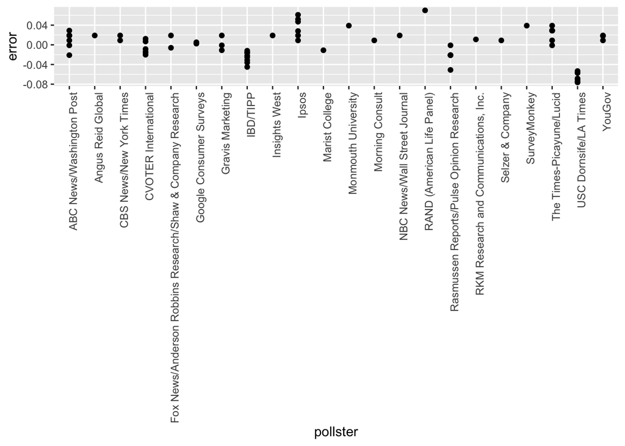

```r
# Add variable called `error` to the object `polls` that contains the difference between d_hat and the actual difference on election day. Then make a plot of the error stratified by pollster.
polls %>% mutate(error = d_hat - 0.021) %>% ggplot(aes(x = pollster, y = error)) + geom_point() + theme(axis.text.x = element_text(angle = 90, hjust = 1))
```

## **Comparing to actual results by pollster - multiple polls**

Remake the plot you made for the previous exercise, but only for pollsters that took five or more polls.

You can use dplyr tools `group_by` and `n` to group data by a variable of interest and then count the number of observations in the groups. The function `filter` filters data piped into it by your specified condition.

For example:

```
data %>% group_by(variable_for_grouping)
    %>% filter(n() >= 5)
```

Instructions

- Define a new variable `errors` that contains the difference between the estimated difference between the proportion of voters and the actual difference on election day, 0.021.
- Group the data by pollster using the `group_by` function.
- Filter the data by pollsters with 5 or more polls.
- Use `ggplo`t to create the plot of errors by pollster.
- Add a layer with the function `geom_point`.

```r
# The `polls` object has already been loaded. Examine it using the `head` function.
head(polls)
```

```
##   state  startdate    enddate
## 1  U.S. 2016-11-03 2016-11-06
## 2  U.S. 2016-11-01 2016-11-07
## 3  U.S. 2016-11-02 2016-11-06
## 4  U.S. 2016-11-04 2016-11-07
## 5  U.S. 2016-11-03 2016-11-06
## 6  U.S. 2016-11-03 2016-11-06
##                                                     pollster grade
## 1                                   ABC News/Washington Post    A+
## 2                                    Google Consumer Surveys     B
## 3                                                      Ipsos    A-
## 4                                                     YouGov     B
## 5                                           Gravis Marketing    B-
## 6 Fox News/Anderson Robbins Research/Shaw & Company Research     A
##   samplesize population rawpoll_clinton rawpoll_trump rawpoll_johnson
```

[output cut: 20 more lines]

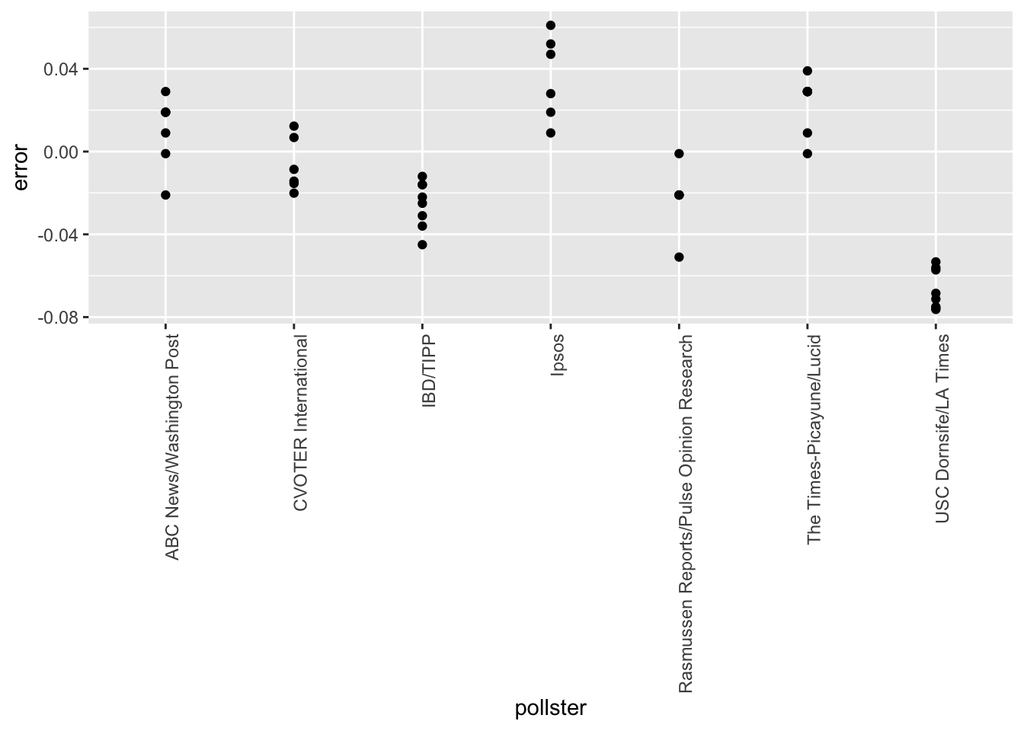

```r
# Add variable called `error` to the object `polls` that contains the difference between d_hat and the actual difference on election day. Then make a plot of the error stratified by pollster, but only for pollsters who took 5 or more polls.
polls %>% mutate(error = d_hat - 0.021) %>% group_by(pollster) %>% filter(n() >= 5) %>% ggplot(aes(x = pollster, y = error)) + geom_point() + theme(axis.text.x = element_text(angle = 90, hjust = 1))
```